# K-means Clustering

```r
library(tidyverse)
library(cluster)
library(factoextra)
library(dendextend)
library(GGally)
```

```r
edu_data <- read_csv("data/school_data.csv")
```

```r
edu_clean <- edu_data %>%
  mutate(urban_pop = urban_pop / 100) %>%
  column_to_rownames("X1")

edu_scale <- edu_clean %>%
  mutate(across(everything(), scale))
```

# K-means

If we have k clusters, we’ll have k midpoints

so if we have two clusters, we’ll have two midpoints

Hierarchical clustering is very good for showing the distances between points, but one way it falls down (apart from displaying large [long] datasets), is in when it groups the points. Over time it will be correct (tending to lower number of clusters), but at higher cluster numbers, we might find points slightly “mis-clustered”.

K-means on the other hand:

- Shows your final groupings for a given number of clusters
- We lose some granularity, but it can be possible to tell immediately what cluster a new point belongs to.

## K-means process

`kmeans()`:

repeats this until “good” clustering:

- plots k centres randomly
- assigns data points into a cluster based on the closest centre
- relocates the centres to the centre of their cluster

Implementing kmeans

Our data: education data about schooling in the US

Looking at home schooling and urban population again:

```r
edu_scale %>%
  pivot_longer(cols = everything(),
               names_to = "var",
               values_to = "value") %>%
  group_by(var) %>%
  summarise(mean = mean(value),
            sd = sd(value)
            )
```

| var | mean | sd |
| --- | --- | --- |
| home_school | 1.046201e-16 | 1 |
| private_school | 2.113696e-16 | 1 |
| state_school | 8.798030e-18 | 1 |
| urban_pop | -4.332808e-16 | 1 |

mean = 0 sd = 1

Data is scaled and ready for clustering

```r
kmeans_edu
```

```
K-means clustering with 6 clusters of sizes 11, 4, 8, 10, 10, 7

Cluster means:
  home_school state_school  urban_pop private_school
1  -0.1642225   -0.3658283 -0.2822467    -0.11697538
2   0.4562038    0.9358314  0.6190084     2.26533514
3   0.8666035    1.2103171  0.8262657     0.84936722
4  -1.1727674   -1.2078573 -1.0045069    -1.10202608
5  -0.6286291   -0.4086988  0.9506200    -0.38883734
6   1.5803956    0.9662584 -0.7775109     0.04844071

Clustering vector:
       Alabama         Alaska        Arizona       Arkansas     California       Colorado    Connecticut       Delaware
             6              2              3              1              2              2              5              5
       Florida        Georgia         Hawaii          Idaho       Illinois        Indiana           Iowa         Kansas
             3              6              5              4              3              1              4              1
      Kentucky      Louisiana          Maine       Maryland  Massachusetts       Michigan      Minnesota    Mississippi
             1              6              4              3              5              3              4              6
      Missouri        Montana       Nebraska         Nevada  New Hampshire     New Jersey     New Mexico       New York
             1              1              1              2              4              5              3              3
North Carolina   North Dakota           Ohio       Oklahoma         Oregon   Pennsylvania   Rhode Island South Carolina
             6              4              5              1              1              5              5              6
  South Dakota      Tennessee          Texas           Utah        Vermont       Virginia     Washington  West Virginia
             4              6              3              5              4              1              5              4
     Wisconsin        Wyoming
             4              1

Within cluster sum of squares by cluster:
[1] 7.788275 6.257771 5.888384 7.443899 9.326266 6.128432
 (between_SS / total_SS =  78.1 %)

Available components:

[1] "cluster"      "centers"      "totss"        "withinss"     "tot.withinss" "betweenss"    "size"         "iter"
[9] "ifault"
```

1. We get the number of points in each cluster (11, 4, 8, 10, 10, 7)

```r
kmeans_edu$size
```

2. We get the positions of the final clusters

```r
kmeans_edu$centers
```

```
  home_school state_school  urban_pop private_school
1  -0.1642225   -0.3658283 -0.2822467    -0.11697538
2   0.4562038    0.9358314  0.6190084     2.26533514
3   0.8666035    1.2103171  0.8262657     0.84936722
4  -1.1727674   -1.2078573 -1.0045069    -1.10202608
5  -0.6286291   -0.4086988  0.9506200    -0.38883734
6   1.5803956    0.9662584 -0.7775109     0.04844071
```

3. The assigned cluster for each row

```r
kmeans_edu$cluster
```

4. Sum of squares within each cluster

```r
kmeans_edu$withinss
```

```
[1] 7.788275 6.257771 5.888384 7.443899 9.326266 6.128432
```

Total within cluster sum of squares:

- how far is each point from its cluster centre?
- square to remove +ve and -ve cancellation
- get total

kmeans plays nicely with {broom}

| home_school | state_school | urban_pop | private_school | size | withinss | cluster |
| --- | --- | --- | --- | --- | --- | --- |
| -0.1642225 | -0.3658283 | -0.2822467 | -0.11697538 | 11 | 7.788275 | 1 |
| 0.4562038 | 0.9358314 | 0.6190084 | 2.26533514 | 4 | 6.257771 | 2 |
| 0.8666035 | 1.2103171 | 0.8262657 | 0.84936722 | 8 | 5.888384 | 3 |
| -1.1727674 | -1.2078573 | -1.0045069 | -1.10202608 | 10 | 7.443899 | 4 |
| -0.6286291 | -0.4086988 | 0.9506200 | -0.38883734 | 10 | 9.326266 | 5 |
| 1.5803956 | 0.9662584 | -0.7775109 | 0.04844071 | 7 | 6.128432 | 6 |

| .rownames | home_school | state_school | urban_pop | private_school | .cluster |
| --- | --- | --- | --- | --- | --- |
| Alabama | 1320 | 23600 | 58 | 2120 | 6 |
| Alaska | 1000 | 26300 | 48 | 4450 | 2 |
| Arizona | 810 | 29400 | 80 | 3100 | 3 |
| Arkansas | 880 | 19000 | 50 | 1950 | 1 |
| California | 900 | 27600 | 91 | 4060 | 2 |
| Colorado | 790 | 20400 | 78 | 3870 | 2 |
| Connecticut | 330 | 11000 | 77 | 1110 | 5 |
| Delaware | 590 | 23800 | 72 | 1580 | 5 |
| Florida | 1540 | 33500 | 80 | 3190 | 3 |
| Georgia | 1740 | 21100 | 60 | 2580 | 6 |

[output cut: 40 more lines]

augment nicely adds the cluster information (what cluster each point is in) to your original data.

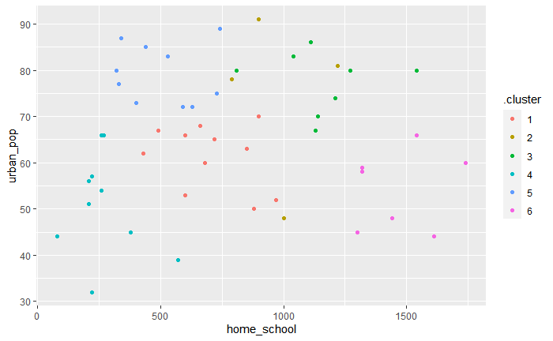

Help for picking a number of clusters

Performing and plotting kmeans for a chosen number of clusters

## Choosing the number of clusters

Method 1: Elbow Method method 2: Silhouette coefficient Method 3: Gap statistic

### Elbow method (within sum of squares)

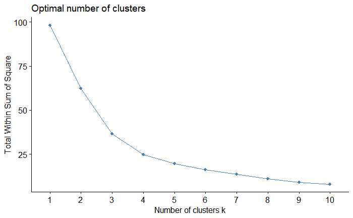

At what point do we start to see less improvement in total within sum of squares when increasing the number of clusters? (where is the elbow?)

k = 3 or 4

### Silhouette coefficient

Looks at separation distance between the clusters. So how dissimilar are the clusters?

```r
# from `factoextra` package

fviz_nbclust(edu_scale %>% select(urban_pop, home_school),
             FUNcluster = kmeans,
             method = "silhouette",
             nstart = 20)
```

[output not shown]

### Gap statistic

```
Clustering k = 1,2,..., K.max (= 10): .. done
Bootstrapping, b = 1,2,..., B (= 100)  [one "." per sample]:
.................................................. 50
.................................................. 100
```

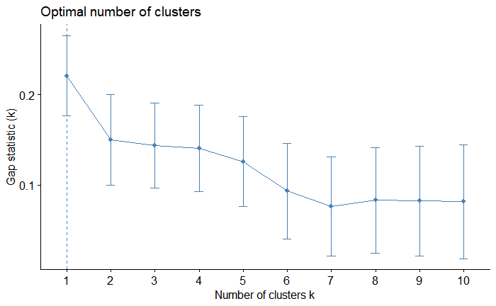

```r
fviz_nbclust(edu_scale %>% select(urban_pop, home_school),
             FUNcluster = kmeans,
             method = "gap_stat",
             nstart = 20)
```

Anywhere you see a decrease going from current k to k + 1 is a reasonable choice for k

so here reasonable choices : 1, 2, 3, 4, 5, 6

So we’ll try 2 clusters and 4 clusters

### K = 2

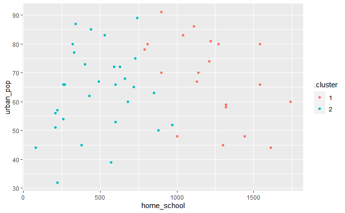

```r
set.seed(123)

kmeans_edu2 <- kmeans(edu_scale, centers = 2, nstart = 20)

augment(kmeans_edu2, edu_clean) %>%
  ggplot(aes(home_school, urban_pop, colour = .cluster)) +
  geom_point()
```

### K = 4

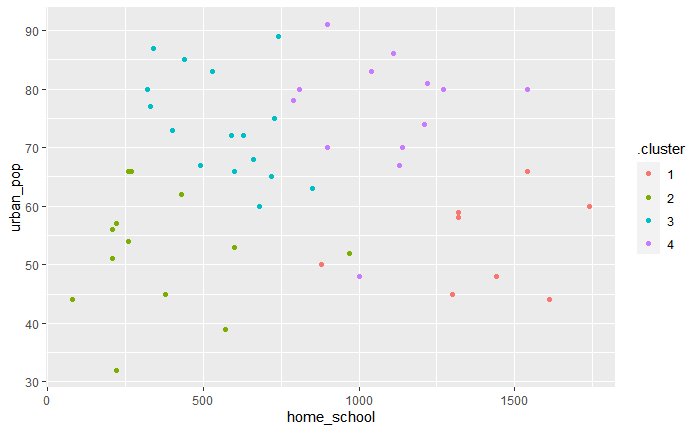

```r
set.seed(123)

kmeans_edu4 <- kmeans(edu_scale, centers = 4, nstart = 20)

augment(kmeans_edu4, edu_clean) %>%
  ggplot(aes(home_school, urban_pop, colour = .cluster)) +
  geom_point()
```

### K = 5

| .rownames | home_school | state_school | urban_pop | private_school | .cluster |
| --- | --- | --- | --- | --- | --- |
| Alabama | 1320 | 23600 | 58 | 2120 | 5 |
| Alaska | 1000 | 26300 | 48 | 4450 | 2 |
| Arizona | 810 | 29400 | 80 | 3100 | 2 |
| Arkansas | 880 | 19000 | 50 | 1950 | 4 |
| California | 900 | 27600 | 91 | 4060 | 2 |
| Colorado | 790 | 20400 | 78 | 3870 | 2 |
| Connecticut | 330 | 11000 | 77 | 1110 | 3 |
| Delaware | 590 | 23800 | 72 | 1580 | 3 |
| Florida | 1540 | 33500 | 80 | 3190 | 2 |
| Georgia | 1740 | 21100 | 60 | 2580 | 5 |

[output cut: 40 more lines]

## Summary

K-means is sensitive to:

- outliers (solution: remove, use a less sensitive clustering algorithm like `kmedoids` [`pam`])
- unscaled data (solution : scale your data)
- the initial centroid location (possible solution: have a higher nstart value)

just a general observation: clustering isn’t always suitable / produces a valuable result

`kmeans()` will run on any numerical data, whether it’s useful or not is context / data dependant